# HW1_exer2

Group11

9/11/2020

# 1 Install and load package of quantmod

# 2 Data using quantmod

It gives the dataset from yahoo with timescale of 2019-01-01 till today.

[output not shown]

```
##            VALE.Open VALE.High VALE.Low VALE.Close VALE.Volume VALE.Adjusted
## 2019-01-02     12.94     13.48    12.92      13.47    22120700      13.12351
## 2019-01-03     13.36     13.38    12.82      12.83    27666700      12.49998
## 2019-01-04     13.35     14.09    13.34      14.02    42880100      13.65937
## 2019-01-07     14.23     14.28    13.80      13.83    26186100      13.47425
## 2019-01-08     13.94     14.15    13.85      14.06    20270400      13.69834
## 2019-01-09     14.51     14.66    14.43      14.51    30852000      14.13676
```

```
##            CSCO.Open CSCO.High CSCO.Low CSCO.Close CSCO.Volume CSCO.Adjusted
## 2019-01-02     42.28     43.20    42.21      42.95    23833500      40.75457
## 2019-01-03     42.30     42.41    40.96      41.07    29606700      39.27241
## 2019-01-04     41.85     43.00    41.53      42.92    27515000      41.04143
## 2019-01-07     42.86     43.65    42.76      43.21    19488100      41.31874
## 2019-01-08     43.57     43.94    43.10      43.56    22071400      41.65343
## 2019-01-09     43.87     43.87    43.17      43.32    22640000      41.42393
```

```
##            INTC.Open INTC.High INTC.Low INTC.Close INTC.Volume INTC.Adjusted
## 2019-01-02     45.96     47.47    45.77      47.08    18774600      45.14560
## 2019-01-03     46.15     46.28    44.39      44.49    32267300      42.66201
## 2019-01-04     45.84     47.57    45.54      47.22    35447300      45.27984
## 2019-01-07     47.10     48.00    46.75      47.44    22736800      45.49080
## 2019-01-08     47.80     48.03    46.78      47.74    22749200      45.77847
## 2019-01-09     47.96     48.57    47.78      48.01    22554500      46.03737
```

```
##            WFC.Open WFC.High WFC.Low WFC.Close WFC.Volume WFC.Adjusted
## 2019-01-02    45.53    46.95   45.41     46.94   20295200     43.58313
## 2019-01-03    46.65    47.35   46.37     46.57   22262000     43.23959
## 2019-01-04    47.42    48.11   47.20     47.95   23343600     44.52090
## 2019-01-07    47.78    48.23   47.54     47.64   21858000     44.23307
## 2019-01-08    47.90    48.16   46.92     47.54   19702900     44.14022
## 2019-01-09    47.51    47.98   47.08     47.80   18837700     44.38163
```

This is an alternative option to fetch the dataset as mentioned above.

```r
fourcom <- c("VALE","CSCO","INTC","WFC")
getSymbols(fourcom, src="yahoo",from = "2019-01-01", to = Sys.Date(),getSymbols.warning4.0=FALSE) # fetch data from yahoo
```

# 3 Plotting pf closing price from 2019-01-01 till today

The following code provides the closing price of the four stocks.

```r
sample.ss <- merge(VALE$VALE.Close,CSCO$CSCO.Close,INTC$INTC.Close,WFC$WFC.Close)
sample.xts <- as.xts(sample.ss) #Convert data to xts file
head(sample.xts) #show the top 6 observations
```

```
##            VALE.Close CSCO.Close INTC.Close WFC.Close
## 2019-01-02      13.47      42.95      47.08     46.94
## 2019-01-03      12.83      41.07      44.49     46.57
## 2019-01-04      14.02      42.92      47.22     47.95
## 2019-01-07      13.83      43.21      47.44     47.64
## 2019-01-08      14.06      43.56      47.74     47.54
## 2019-01-09      14.51      43.32      48.01     47.80
```

Method 1: Plotting of closing price has done using ggplot approach.

[figure not shown]

Method 2: an alternative way to plot using xts

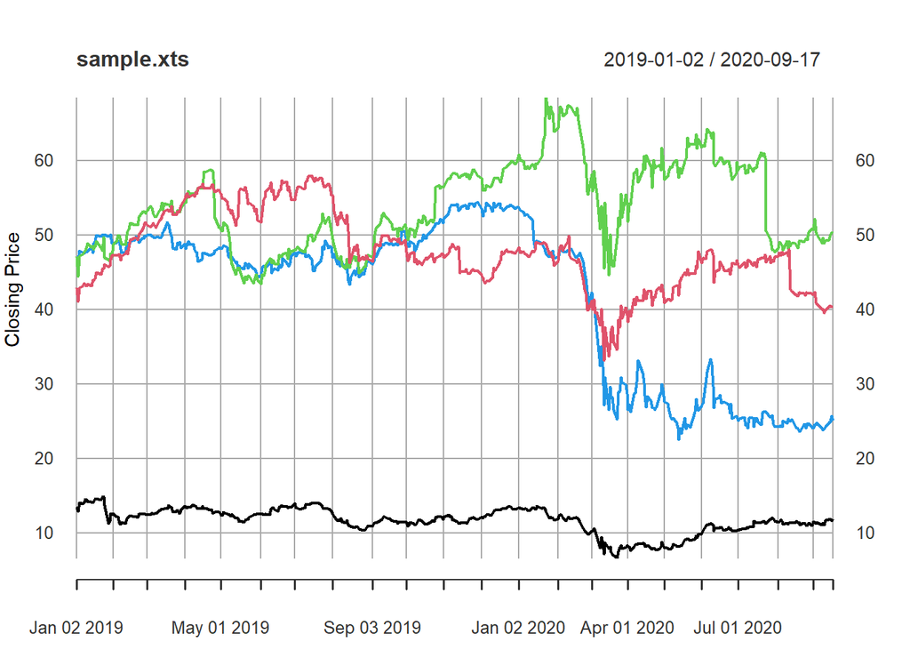

Method 3: The conventional method of plotting.

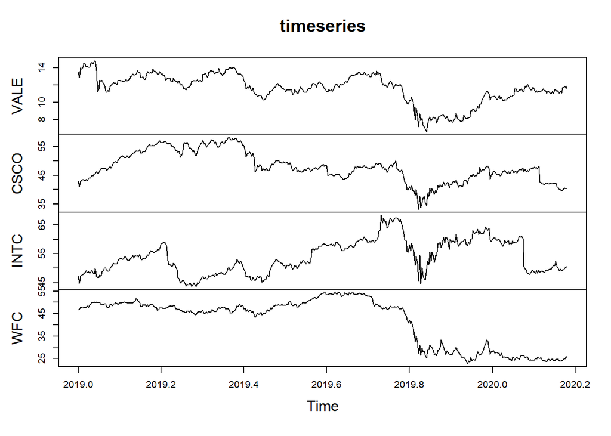

Method 4: This is one of the most interesting method which gives in an animated version.

[interactive chart not shown]

# 4 Candle chart over the last four months

Method 1: The conventional method for plotting of candle chart.

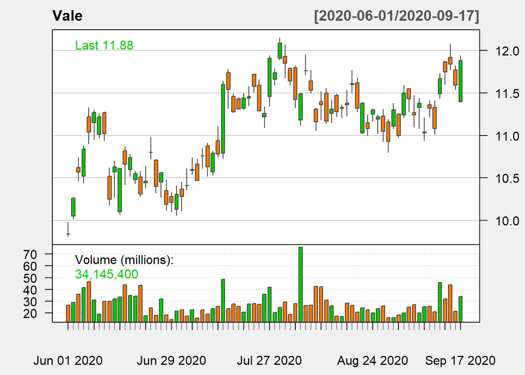

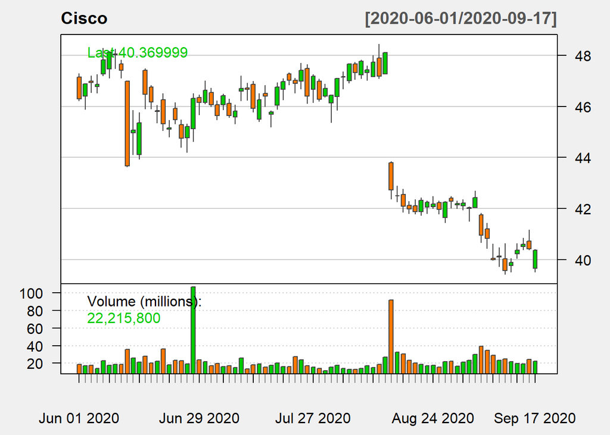

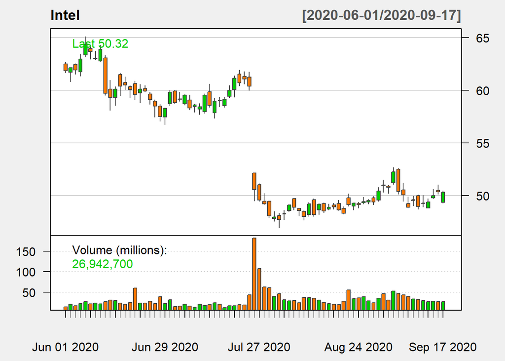

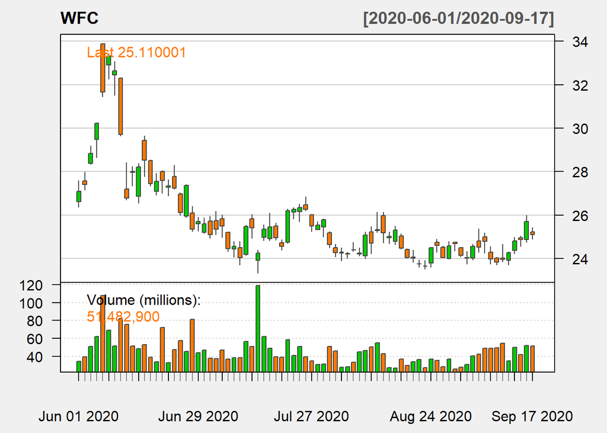

Method 2 :Plotting in a single file.

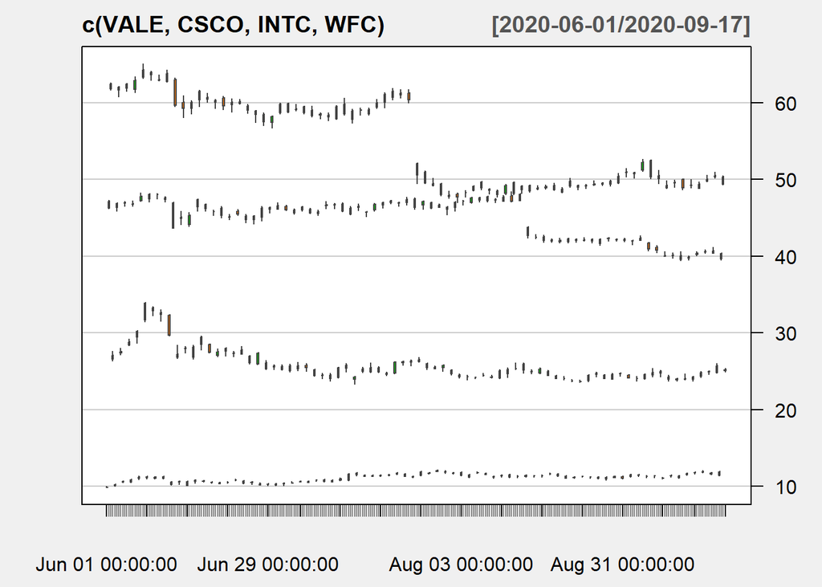

```r
candleChart(c(VALE,CSCO,INTC,WFC),theme="white", subset='last 4 months',TA=NULL)
```

```r
# A candle chart contain 4 stocks
```

# 5 Mean and Variance of closing price

Method 1:

```
##                 mean   variance
## Vale_stock  11.60951   2.826351
## WF_stock    41.75155 112.746153
## Cisco_stock 47.83775  27.075165
## Intel_stock 53.83509  33.920287
```

Method 2:

```
## # A tibble: 4 x 3
##   Companys   avg   std
##   <chr>    <dbl> <dbl>
## 1 VALE      11.6  1.68
## 2 CSCO      47.8  5.20
## 3 INTC      53.8  5.82
## 4 WFC       41.8 10.6
```

# 6 Sharpe ratio

Here, the daily return() estimates the value of Rt.

```
##        vale       cisco       intel  wellsfargo
## -0.05659682  0.28807361  0.35323613 -0.03800431
```

# 7 Portfolio variance for individual as well as combination of all.

Method 1:

This is the individual variances.

```
##         vale        cisco        intel   wellsfargo
## 0.0009014682 0.0002843969 0.0003233808 0.0003230565
```

Equally weighted portfolio variance

```
## [1] 0.0002499203
```

Checking whether equally weighted variances is less than the individual variance.

```
##       vale      cisco      intel wellsfargo
##       TRUE       TRUE       TRUE       TRUE
```

It showed that the equally weighted portfolio variance is less than the individual variances.

Method 2:

```r
daliyreALLree <- data.frame(date=daliyreAll)
names(daliyreALLree)=c("VALE","CSCO","INTC","WFC")
daliynew<- daliyreALLree %>%
                mutate( portfolio = (VALE + CSCO + INTC + WFC)/4)
var(x= daliynew$portfolio, y=daliynew$portfolio)
```

```
## [1] 0.0002512982
```

```r
apply(daliyreAll, 2, var)
```

```
##         VALE         CSCO         INTC          WFC
## 0.0008690490 0.0002932803 0.0003168554 0.0003351973
```

*The variance of this portfolio is less than variances of every individual returns of the stocks.*